# Assignment 1 Report

This is an outline for your report to ease the amount of work required to create your report. Jupyter notebook supports markdown, and I recommend you to check out this [cheat sheet](https://github.com/adam-p/markdown-here/wiki/Markdown-Cheatsheet). If you are not familiar with markdown.

Before delivery, **remember to convert this file to PDF**. You can do it in two ways:

1. Print the webpage (ctrl+P or cmd+P)
2. Export with latex. This is somewhat more difficult, but you'll get somehwat of a "prettier" PDF. Go to File -> Download as -> PDF via LaTeX. You might have to install nbconvert and pandoc through conda; `conda install nbconvert pandoc`.

# Task 1

[figure not shown]

```python
import numpy as np
from scipy.ndimage import convolve

image = np.array([[2, 1, 2, 3, 1],
                  [3, 9, 1, 1, 4],
                  [4, 5, 0, 7, 0]])

kernel = np.array([[-1, 0, 1],
                   [-2, 0, 2],
                   [-1, 0, 1]])

convolved_image_s = convolve(image, kernel, mode='constant')
convolved_image_s
```

```
array([[-11,   2,   4,  -1,   7],
       [-24,   8,  12,  -5,  12],
       [-19,  10,   4,  -3,  15]])
```

### is the negative of what we got when we did it by hand!

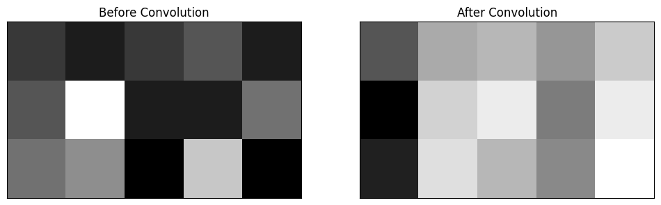

```python
import matplotlib.pyplot as plt

def plot_images(before, after, before_title="Before Convolution", after_title="After Convolution"):
    fig, axs = plt.subplots(1, 2, figsize=(12, 6))

    axs[0].imshow(before, cmap='gray', interpolation='nearest')
    axs[0].set_title(before_title)
    axs[0].set_xticks([])
    axs[0].set_yticks([])

    axs[1].imshow(after, cmap='gray', interpolation='nearest')
    axs[1].set_title(after_title)
    axs[1].set_xticks([])
    axs[1].set_yticks([])

    plt.show()

plot_images(image, convolved_image_s)
```

### The convolve image seem to capture the vertical edges of the image, and ignoring the horizontal edges. This is what we expect from sobels kernel, as it is a vertical edge detector.

```python
import cv2

image_float32 = np.float32(image)

kernel_float32 = np.float32(kernel)

convolved_image_cv = cv2.filter2D(image_float32, -1, kernel_float32, borderType=cv2.BORDER_CONSTANT)

convolved_image_cv_int = np.int32(convolved_image_cv)
convolved_image_cv_int
```

```
array([[ 11,  -2,  -4,   1,  -7],
       [ 24,  -8, -12,   5, -12],
       [ 19, -10,  -4,   3, -15]], dtype=int32)
```

#### OpenCV seem to give the same result as we got when we calulated by hand.

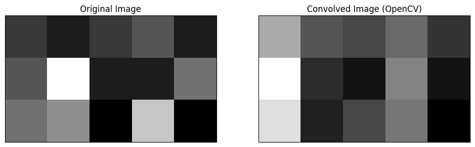

```python
plot_images(image, convolved_image_cv_int, before_title="Original Image", after_title="Convolved Image (OpenCV)")
```

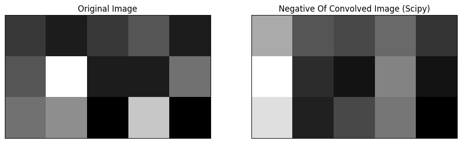

```python
plot_images(image, -convolved_image_s, before_title="Original Image", after_title="Negative Of Convolved Image (Scipy)")
```

## task 1b)

**Convolutional Layer**: Serves as the feature detector, employing filters to highlight elements like edges in the input image. While effective in feature identification, it does not inherently reduce the network's sensitivity to slight positional shifts of these features.

**Activation Function**: Implements functions such as ReLU or Sigmoid to add non-linearity, enabling complex pattern recognition. However, these functions do not contribute to translational invariance, focusing instead on signal transformation at the neuron level.

**Max Pooling**: This layer is crucial for enhancing translational invariance. By downsampling the feature maps through selecting maximum values within specific areas, it reduces the network's sensitivity to small shifts, ensuring consistent feature recognition despite minor positional changes.

## task 1c)

The formula used to calculate the output size of a feature map in a convolutional layer is:

$$ O = \frac{W - F + 2P}{S} + 1 $$

where:

- $O$ is the output size (height or width),
- $W$ is the corresponding input size (height or width),
- $F$ is the kernel size,
- $P$ is the padding applied to one side of the input, and
- $S$ is the stride of the convolution.

To maintain the same spatial dimensions for the output as the input, we set $O = W$ and rearrange the formula to solve for the padding $P$ necessary:

$$ W = \frac{W - F + 2P}{S} + 1 $$

Given:

- **Kernel Size** = 7 × 7
- **Stride** = 1

$$ P = \frac{K - 1}{2} = \frac{7 - 1}{2} = 3 $$

This result means that by applying a padding of 3 on all sides of the input, the spatial dimensions (both height and width) of the output feature maps will remain the same as those of the input.

## Task 1d)

- Input size $W_1$ = (512, 512), assuming square input matrices: **W = H**.
- Output size $W_2$ = (508, 508)
- Stride (S) = 1
- Padding (P) = 0

$$ W_2 = W_1 - F + 2P + 1 $$

$$ F = W_1 - W_2 + 2P + 1 $$

$$ F = 512 - 508 + 2 \times 0 + 1 = 5 $$

The kernel size **F** is 5x5.

## Task 1e)

$$ W_3 = \frac{W_2 - F}{S} + 1 $$

where:

- $W_3$ is the output size after pooling,
- $W_2$ is the input size to the pooling layer (508x508),
- $F$ is the size of the pooling filter,
- $S$ is the stride of the pooling operation.
- Filter size ($F$) = 2,
- Stride ($S$) = 2,

$$ W_3 = \frac{508 - 2}{2} + 1 = 254 $$

The spatial dimensions of the pooled feature maps in the first pooling layer are **254 × 254.

## Task 1f)

$$ W_4 = \frac{W_3 - F + 2P}{S} + 1 $$

where:

- $W_4$ feature map size after the convolutional layer
- $W_3$ input size to the convolutional layer = 254
- $F$ spatial dimensions of the convolutional kernel = 3x3
- $P$ = 0
- $S$ = 1

$$ W_4 = \frac{254 - 3 + 2 \times 0}{1} + 1 = 252 $$

The size of feature maps after the convolutional layer is 252x252.

## Task 1g)

**Convolutional Layers:**

The number of parameters in a convolutional layer can be calculated using the following formula:

$$ \text{Number of parameters} = (f_w \times f_h \times C_i \times F) + F(b) $$

- $f_w$: Width of the filter kernel (e.g., 5 in your example).
- $f_h$: Height of the filter kernel (e.g., 5 in your example).
- $C_i$: Number of channels in the input image (e.g., 3 for RGB images).
- $F$: Number of filters used in the layer.
- $b$: Bias term added to each filter output (allowing non-zero output even with zero input).

**Convolutional Layers:**

| Layer | Input Channels | Filters | Filter Size | Bias Terms | Parameters |
| --- | --- | --- | --- | --- | --- |
| 1 | 3 (RGB) | 32 | 5x5 | 32 | 2432 |
| 2 | 32 | 64 | 5x5 | 64 | 51264 |
| 3 | 64 | 128 | 5x5 | 128 | 204928 |

**Fully Connected Layers:**

The number of parameters in a fully connected layer can be calculated using the following formula:

$$ \text{Number of parameters} = (I + 1) \times H(b) $$

- $I$: Number of elements in the input vector.
- $H$: Number of neurons in the fully connected layer.
- $b$: Bias term added to each neuron (allowing non-zero output even with zero input).

**Fully Connected Layers:**

After flattening the convolutional layers, the vector size becomes 4 * 4 * 128 = 2048.

| Layer | Input Size | Hidden Units/Output Classes | Bias Terms | Parameters |
| --- | --- | --- | --- | --- |
| 1 | 2048 | 64 | 64 | 131136 |
| 2 | 64 | 10 (Output) | 10 | 650 |

**Total Parameters:**

We can calculate the total number of parameters by summing the parameters from each layer:

Total Parameters = 2432 + 51264 + 204928 + 131136 + 650 = **390,410**

Therefore, the network has **390,410** parameters.

# Task 2

### Task 2a)

#### Network architecture:

| Layer | Layer Type | Number of Filters | Activation Function | Kernel Size | Stride | Padding |
| --- | --- | --- | --- | --- | --- | --- |
| 1 | Conv2D | 32 | ReLU | 5 | 1 | 2 |
| 1 | MaxPool2D | - | - | 2 | 2 | - |
| 2 | Conv2D | 64 | ReLU | 5 | 1 | 2 |
| 2 | MaxPool2D | - | - | 2 | 2 | - |
| 3 | Conv2D | 128 | ReLU | 5 | 1 | 2 |
| 3 | MaxPool2D | - | - | 2 | 2 | - |
|  | Flatten | - | - | - | - | - |
| 4 | Fully-Connected | 64 | ReLU | - | - | - |
| 5 | Fully-Connected | 10 | Softmax | - | - | - |

[figure not shown]

### Task 2b)

Final Training Loss: 0.352, Final Training Accuracy: 0.885

Final Validation Loss: 0.798, Final Validation Accuracy: 0.735

Final Test Loss: 0.836, Final Test Accuracy: 0.736

# Task 3

### Task 3a)

To obtain a model that reaches a validation accuracy of at least 0.75, we implemented this architecture:

#### Convolutional Neural Network Architecture

| Layer | Layer Type | Number of Filters | Activation Function | Kernel Size | Stride | Padding | BatchNorm |
| --- | --- | --- | --- | --- | --- | --- | --- |
| 1 | Conv2D | 64 | ReLU (0.1) | 3 | 1 | 1 | Yes |
| 1 | MaxPool2D | - | - | 2 | 2 | - | - |
| 2 | Conv2D | 128 | ReLU (0.1) | 3 | 1 | 1 | Yes |
| 2 | MaxPool2D | - | - | 2 | 2 | - | - |
| 3 | Conv2D | 256 | ReLU (0.1) | 3 | 1 | 1 | Yes |
| 3 | MaxPool2D | - | - | 2 | 2 | - | - |
|  | Flatten | - | - | - | - | - | - |
| 4 | Fully-Connected | 512 | ReLU (0.1) | - | - | - | - |
| 5 | Fully-Connected | 10 | - | - | - | - | - |

We also added BatchNorm2d after each convolutional layer to improve the training speed and accuracy. Batch normalization (BatchNorm2d) addresses internal covariate shift in convolutional neural networks (CNNs) by normalizing activations across channels within a mini-batch. The advatage of using BatchNorm2d is that it reduces the training time and improves the accuracy of the model. It also makes the model more robust to different learning rates and initializations.

We reduced the filter size from 5x5 to 3x3. This is because smaller filter sizes are able to capture more fine-grained details in the input image, which can be beneficial for image classification tasks. Smaller filter sizes also reduce the number of parameters in the model, which can help to reduce overfitting and improve generalization.

Batch size = 64.

Learning rate = 0.01

Early stopping = 10

Optimizer = SGD (Stochastich Gradient Descent)

### Task 3b)

Final Training Loss: 0.038, Final Training Accuracy: 0.994

Final Validation Loss: 0.846, Final Validation Accuracy: 0.770

Final Test Loss: 0.933, Final Test Accuracy: 0.760

[figure not shown]

### Task 3c)

**Increased Network Capacity (More Neurons):**

- **Effect:** Increased model capacity to learn complex non-linear relationships between input features and target classes.

**Smaller Filters (3x3 vs. 5x5):**

- **Effect:**
  - Reduced overfitting by focusing on capturing local image features.
  - Lower computational cost due to fewer parameters compared to larger filters.

**Lower Learning Rate (0.01):**

- **Effect:**
  - Improved convergence by taking smaller steps during training, potentially avoiding local minima in the loss landscape.
  - Reduced risk of large parameter updates leading to unstable training behavior.

**Larger Early Stopping Patience (10):**

- **Effect:**
  - Mitigated overfitting by allowing the model to train for a longer period, potentially achieving better performance on the validation set.
  - Avoided premature stopping while the model was still learning from the training data.

**Batch Normalization (BatchNorm2d):**

- **Effect:**
  - Faster convergence by addressing internal covariate shift and stabilizing the distribution of activations during training.
  - Reduced sensitivity to weight initialization, making the model less prone to getting stuck in poor initial parameter configurations.

**What did not work:**

- **Increased Learning Rate:**
  - A learning rate of 0.1 led to unstable training behavior, with the model failing to converge to a good solution.
  - Larger learning rates can cause the model to overshoot the optimal parameter values, leading to poor performance.
  - A smaller early stopping patience (e.g., 5) led to premature stopping, preventing the model from learning the underlying patterns in the training data.
  - Larger filter sized that 5x5 did not improve the model performance. This is because larger filter sizes are less effective at capturing fine-grained details in the input image, which can be detrimental for image classification tasks.
  - Larger filter sizes also increase the number of parameters in the model, which can lead to overfitting and reduced generalization.

### Task 3d)

- We got the best improvement from simply increasing the number of neurons in the both the convolutional layers and the fully connected layers.

### Task 3e)

**Table:** The best Neural Network Architecture

| Layer | Layer Type | Number of Filters | Activation Function | Kernel Size | Stride | Padding | BatchNorm | Dropout |
| --- | --- | --- | --- | --- | --- | --- | --- | --- |
| 1 | Conv2D | 128 | LeakyReLU (0.1) | 3 | 1 | 1 | Yes | 0.1 |
| 1 | MaxPool2D | - | - | 2 | 2 | - | - | - |
| 2 | Conv2D | 256 | LeakyReLU (0.1) | 3 | 1 | 1 | Yes | 0.1 |
| 2 | MaxPool2D | - | - | 2 | 2 | - | - | - |
| 3 | Conv2D | 512 | LeakyReLU (0.1) | 3 | 1 | 1 | Yes | - |
| 3 | MaxPool2D | - | - | 2 | 2 | - | - | - |
| 4 | Conv2D | 1024 | LeakyReLU (0.1) | 3 | 1 | 1 | Yes | - |
| 4 | MaxPool2D | - | - | 2 | 2 | - | - | - |
|  | AdaptiveAvgPool2d | - | - | - | - | - | - | - |
|  | Flatten | - | - | - | - | - | - | - |
| 5 | Linear | 1024 | LeakyReLU (0.1) | - | - | - | - | 0.5 |
| 5 | Linear | 1024 | LeakyReLU (0.1) | - | - | - | - | 0.5 |
|  | Linear | 10 | - | - | - | - | - | - |

Final Training Loss: 0.376, Final Training Accuracy: 0.870

Final Validation Loss: 0.556, Final Validation Accuracy: 0.809

Final Test Loss: 0.554, Final Test Accuracy: 0.816

[figure not shown]

#### Note:

By just introducing data augmentation, we were able to improve the model performance up to:

Final Training Loss: 0.376, Final Training Accuracy: 0.873

Final Validation Loss: 0.601, Final Validation Accuracy: 0.793

Final Test Loss: 0.581, Final Test Accuracy: 0.804

[figure not shown]

### Task 3f)

# Task 4

learning rate = 5e-4 early stopping = 10 optimizer = Adam Rezie = 224 batch size = 32

normalization = transforms.Normalize(mean=[0.485, 0.456, 0.406], std=[0.229, 0.224, 0.225])

Final Training Loss: 0.028, Final Training Accuracy: 0.991

Final Validation Loss: 0.341, Final Validation Accuracy: 0.911

Final Test Loss: 0.385, Final Test Accuracy: 0.902

[figure not shown]